# PVLDB

Bibliometric Analysis

Donatus Herre (SLUB Dresden)

2025-07-25

Branches: main / gh-pages

# Count Data

## Works

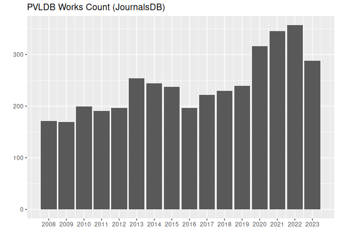

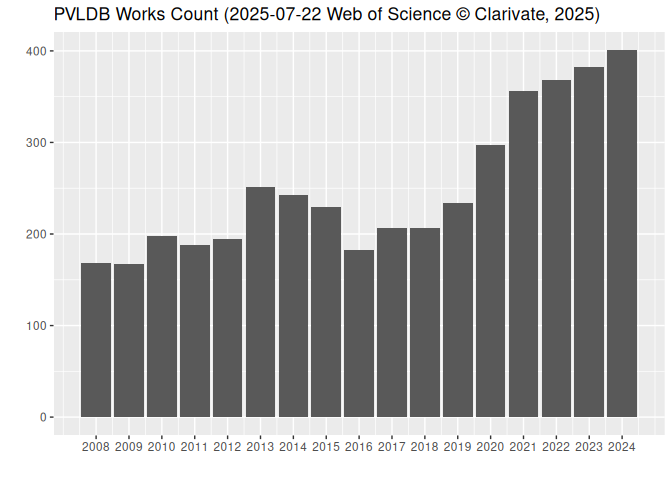

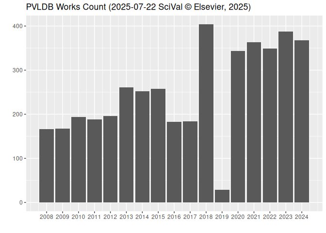

## Citations

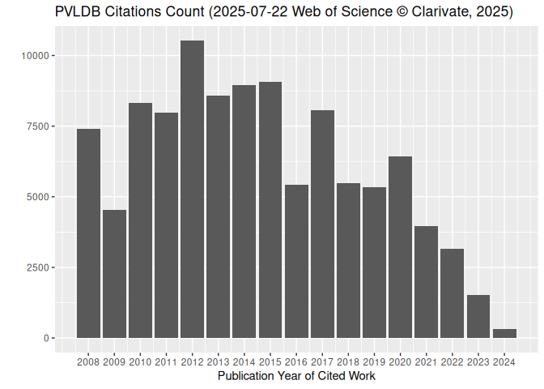

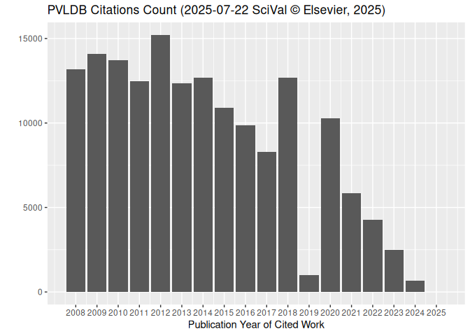

# Raw Data

- JournalsDB (last update: 2025-07-22)
  - journals (`2150-8097`) [JSON, 4.00 KB]

# Data Sources

- [Crossref API](https://api.crossref.org)
  - prefixes
    - [10.1145](https://api.crossref.org/prefixes/10.1145?mailto=bibliometrie@slub-dresden.de)
  - works
    - [filter=issn:2150-8097,has-abstract:true](https://api.crossref.org/works?filter=issn:2150-8097,has-abstract:true&mailto=bibliometrie@slub-dresden.de)
    - [filter=issn:2150-8097,has-references:true](https://api.crossref.org/works?filter=issn:2150-8097,has-references:true&mailto=bibliometrie@slub-dresden.de)
    - [filter=issn:2150-8097&facet=type-name:*](https://api.crossref.org/works?filter=issn:2150-8097&facet=type-name:*&rows=0&mailto=bibliometrie@slub-dresden.de)
    - [filter=issn:2150-8097,type:journal-article](https://api.crossref.org/works?filter=issn:2150-8097,type:journal-article&mailto=bibliometrie@slub-dresden.de)
    - [filter=issn:2150-8097,type:journal-article,has-references:true](https://api.crossref.org/works?filter=issn:2150-8097,type:journal-article,has-references:true&mailto=bibliometrie@slub-dresden.de)
    - [filter=issn:2150-8097&select=DOI,is-referenced-by-count](https://api.crossref.org/works?filter=issn:2150-8097&select=DOI,is-referenced-by-count&mailto=bibliometrie@slub-dresden.de)
- [Crossref OAI](https://oai.crossref.org/oai?verb=Identify)
  - ListSets
    - set=J:10.14778
- [Crossref Depositor Report](https://www.crossref.org/documentation/reports/depositor-report/)
  - journals
    - pubid=J249417
- [Crossref Event Data API](https://www.eventdata.crossref.org/)
  - events
    - [obj-id.prefix=10.14778](https://api.eventdata.crossref.org/v1/events?obj-id.prefix=10.14778&mailto=bibliometrie@slub-dresden.de)
    - [subj-id.prefix=10.14778](https://api.eventdata.crossref.org/v1/events?subj-id.prefix=10.14778&mailto=bibliometrie@slub-dresden.de)
- [DataCite API](https://support.datacite.org/docs/api)
  - dois
    - query=relatedIdentifiers.relatedIdentifier:10.14778*
    - query=relatedIdentifiers.relatedIdentifier:10.14778*&affiliation=true
    - query=relatedIdentifiers.relatedIdentifier:10.14778*&affiliation=true&resource-type-id=dataset
- [DBLP API](https://dblp.org/faq/13501473.html)
  - search/publ/api
    - [streams/journals/pvldb](https://dblp.org/search/publ/api?q=stream%3Astreams%2Fjournals%2Fpvldb%3A&h=1000&format=json)
  - search/venue/api
    - [q=Proceedings of the VLDB Endowment](https://dblp.org/search/venue/api?q=Proceedings%20of%20the%20VLDB%20Endowment&format=json)
- [ISSN Portal LD Service](https://www.issn.org/understanding-the-issn/assignment-rules/issn-linked-data-application-profile/)
  - resource/ISSN
    - [2150-8097](https://portal.issn.org/resource/ISSN/2150-8097?format=json)
  - resource/ISSN-L
    - [2150-8097](https://portal.issn.org/resource/ISSN-L/2150-8097?format=json)
- [JournalsDB API](https://api.journalsdb.org/apidocs/)
  - journals
    - 2150-8097
- [Wikidata](https://www.wikidata.org/wiki/Wikidata:Data_access)
  - Linked Data Interface
    - [Q27722874](https://www.wikidata.org/wiki/Special:EntityData/Q27722874.json)
- [SLUB LOD API](https://data.slub-dresden.de/)
  - resource
    - 591517426
  - source/kxp-de14
    - 591517426

# Usage Terms

This document is licensed under a Creative Commons Attribution 4.0 International License.  
The raw data is made available under the CC0 1.0 Universal Public Domain Dedication.